# Configuración, Exportación y Visualización de Resultados

## Introducción

El paquete `peruocc` está diseñado tanto para la exploración interactiva y rápida de ocurrencias de biodiversidad en memoria, como para flujos de trabajo reproducibles en producción y análisis espacial (SIG).

Esta guía explica: 1. Cómo configurar el directorio de almacenamiento y caché (`peruocc_data_dir()`). 2. La diferencia entre consultas interactivas en memoria (`guardar_resultados = FALSE`) y persistencia en disco (`guardar_resultados = TRUE`). 3. La función dedicada `exportar_resultados()` y los formatos generados (CSV, GeoJSON y Manifiesto de reproducibilidad). 4. La visualización cartográfica con `graficar_ocurrencias()`.

## 1. Configuración del Directorio de Trabajo: `peruocc_data_dir()`

La función `peruocc_data_dir()` permite centralizar opcionalmente la ubicación en el disco donde se almacenarán capas espaciales descargadas en caché y los resultados exportados.

```r
library(peruocc)
```

```r
# Configurar el directorio raíz del proyecto para artefactos (opcional)
peruocc_data_dir("mi-carpeta-proyecto")
```

### ¿Por qué es útil y cómo funciona?

- **Control y Orden del Proyecto**: Mantiene todas las salidas y capas auxiliares organizadas en una única carpeta personalizada en lugar de dispersarlas en la raíz de trabajo.
- **Caché Opcional de Geometrías**: Al configurar una ruta, el paquete guarda copias `.rds` en `cache/`. Las siguientes consultas a esa misma zona cargarán la geometría instantáneamente sin volver a descargarla de internet.
- **Configuración Global Transparente**: Al ejecutar `peruocc_data_dir()`, la ruta se guarda en las opciones de R (`options(peruocc.data_dir = ...)`).

### ¿Qué ocurre si NO ejecuto `peruocc_data_dir()`?

**No habrá ningún error y las consultas funcionarán con normalidad.** * **Caché**: `peruocc` almacena las capas en la memoria RAM de la sesión (`.peruocc_mem_cache`), garantizando cero escrituras en disco no solicitadas. * **Exportaciones**: Si decides exportar archivos más adelante con `exportar_resultados()`, simplemente indica la carpeta deseada mediante el argumento `dir_salida` (por ejemplo, `dir_salida = tempdir()`).

## 2. Ejecución en Memoria vs. Guardado en Disco (`guardar_resultados`)

Todas las funciones principales de búsqueda (`buscar_especies_distrito()`, `buscar_especies_provincia()`, `buscar_especies_peru()`) incluyen el argumento `guardar_resultados`.

```r
# Firma de la función
buscar_especies_distrito(
  distrito,
  departamento = NULL,
  provincia = NULL,
  ...,
  guardar_resultados = FALSE  # <- FALSE por defecto
)
```

### Comparativa: Consultas Experimentales vs. Guardado Automático

| Característica | `guardar_resultados = FALSE` (Por defecto / Experimental) | `guardar_resultados = TRUE` (Guardado Automático) |
| --- | --- | --- |
| **Destino de datos** | Solo memoria RAM en la sesión de R. | Memoria RAM + archivos guardados en disco. |
| **Velocidad de ejecución** | **Más rápida.** Evita la sobrecarga de I/O y serialización espacial. | Requiere tiempo adicional para escribir CSV, GeoJSON y JSON. |
| **Archivos generados** | Ninguno. | `.csv`, `.geojson` y `manifiesto_*.json` en la subcarpeta `processed/`. |
| **Casos de uso** | Análisis exploratorio, filtrado rápido, visualización interactiva y pruebas de parámetros. | Pipelines automatizados, ejecuciones desatendidas o procesamiento en lotes (*batch*). |

### Flujo de Trabajo Recomendado

Para la mayoría de los análisis, la mejor práctica es **trabajar primero en memoria** y luego exportar selectivamente cuando los datos estén listos:

```r
# Paso 1: Consulta rápida en memoria (experimental / interactiva)
resultado <- buscar_especies_distrito(
  distrito = "Miraflores",
  departamento = "Lima",
  provincia = "Lima",
  grupo = "flora",
  limite_por_api = 150
)
```

```
#>
#> ── Búsqueda Integrada: MIRAFLORES (DISTRITO) ───────────────────────────────────
#> • Departamento: Lima
#> • Provincia: Lima
#> • Grupo: flora
#> ℹ Descargando límites de LIMA vía geoperu...
#> ℹ [GBIF] Iniciando búsqueda de ocurrencias...
#> ✔ Polígono simplificado con éxito a tolerancia de 100 metros (WKT: 822 caracteres).
#> ℹ [GBIF] Filtrando por reino Plantae (Flora).
#> ℹ [GBIF] Consultando registros dentro del polígono de MIRAFLORES (límite: "150")...
#> ✔ [GBIF] Búsqueda finalizada. Se filtraron 148 registro(s) que caen dentro del polígono seleccionado.
#> ℹ [iNaturalist] Iniciando búsqueda de ocurrencias...
#> ℹ [iNaturalist] Filtrando por reino Plantae (Flora).
#> ℹ [iNaturalist] Consultando registros dentro de la caja delimitadora de MIRAFLORES (límite: "150")...
#> ℹ [iNaturalist] Se descargaron 150 registros en la caja delimitadora. Aplicando filtro espacial...
#> ✔ [iNaturalist] Búsqueda finalizada. 133 de 150 registros caen dentro del polígono seleccionado.
#> ✔ Consolidación exitosa. Total de registros unificados: 281
#>
#> ── Resumen de Registros ──
#>
#> • GBIF: 148 registro(s)
#> • iNaturalist: 133 registro(s)
#> ✔ Total consolidado: 281 registro(s)
```

```r
# Paso 2: Inspeccionar resultados o graficar
summary(resultado$ocurrencias)
```

```
#>     occurrenceID   sourceRecordID     sourceURL       datasetKey
#>  Length   :281   Length   :281    Length   :281   Length   :281
#>  N.unique :281   N.unique :281    N.unique :281   N.unique :  2
#>  N.blank  :  0   N.blank  :  0    N.blank  :  0   N.blank  :  0
#>  Min.nchar: 10   Min.nchar:  9    Min.nchar: 42   Min.nchar: 36
#>  Max.nchar: 50   Max.nchar: 10    Max.nchar: 50   Max.nchar: 36
#>                                                   NAs      :133
#>
#>       license      basisOfRecord   scientificName decimalLatitude
#>  Length   :281   Length   :281   Length   :281    Min.   :-12.14
#>  N.unique :  8   N.unique :  2   N.unique :119    1st Qu.:-12.13
#>  N.blank  : 20   N.blank  :  0   N.blank  :  0    Median :-12.12
#>  Min.nchar:  0   Min.nchar: 16   Min.nchar: 11    Mean   :-12.12
#>  Max.nchar: 58   Max.nchar: 17   Max.nchar: 58    3rd Qu.:-12.12
#>                                                   Max.   :-12.11
#>
#>  decimalLongitude     eventDate       taxonRank        kingdom
#>  Min.   :-77.05   Length   :281   Length   :281   Length   :281
#>  1st Qu.:-77.04   N.unique :234   N.unique :  1   N.unique :  1
#>  Median :-77.03   N.blank  :  0   N.blank  :  0   N.blank  :  0
#>  Mean   :-77.03   Min.nchar: 10   Min.nchar:  7   Min.nchar:  7
#>  3rd Qu.:-77.03   Max.nchar: 20   Max.nchar:  7   Max.nchar:  7
#>  Max.   :-77.01                   NAs      :133
#>
#>        phylum          class           order           family
#>  Length   :281   Length   :281   Length   :281   Length   :281
#>  N.unique :  2   N.unique :  4   N.unique : 21   N.unique : 35
#>  N.blank  :  0   N.blank  :  0   N.blank  :  0   N.blank  :  0
#>  Min.nchar: 10   Min.nchar:  9   Min.nchar:  6   Min.nchar:  7
#>  Max.nchar: 12   Max.nchar: 15   Max.nchar: 14   Max.nchar: 16
#>  NAs      :133   NAs      :133   NAs      :133   NAs      :133
#>
#>        genus          species        recordedBy  coordinateUncertaintyInMeters
#>  Length   :281   Length   :281   Length   :281   Min.   :   2.0
#>  N.unique : 53   N.unique : 63   N.unique :122   1st Qu.:  12.0
#>  N.blank  :  0   N.blank  :  0   N.blank  :  0   Median :  21.0
#>  Min.nchar:  5   Min.nchar: 11   Min.nchar:  5   Mean   : 285.8
#>  Max.nchar: 16   Max.nchar: 28   Max.nchar: 30   3rd Qu.:  27.5
#>  NAs      :133   NAs      :133   NAs      : 10   Max.   :3945.0
#>                                                  NAs    :54
#>        source         district        province       department
#>  Length   :281   Length   :281   Length   :281   Length   :281
#>  N.unique :  2   N.unique :  1   N.unique :  1   N.unique :  1
#>  N.blank  :  0   N.blank  :  0   N.blank  :  0   N.blank  :  0
#>  Min.nchar:  4   Min.nchar: 10   Min.nchar:  4   Min.nchar:  4
#>  Max.nchar: 11   Max.nchar: 10   Max.nchar:  4   Max.nchar:  4
#>
#>
```

```r
# Paso 3: Si los datos son conformes, exportar a disco
# exportar_resultados(resultado)
```

## 3. Exportación de Resultados y Estructura de Artefactos

La función `exportar_resultados()` toma el objeto devuelto por cualquier búsqueda y genera artefactos estructurados y listos para interoperabilidad:

```r
# Exportación completa (por defecto a processed/ de peruocc_data_dir)
archivos <- exportar_resultados(resultado)

# Exportación personalizada a otra carpeta y formatos específicos:
exportar_resultados(
  resultado = resultado,
  dir_salida = "mis_analisis/capas",
  formatos = c("csv", "geojson")
)
```

### Estructura del Directorio de Salida

Cuando se utiliza `peruocc_data_dir("peruocc-output")`, la estructura queda organizada de la siguiente manera:

```
peruocc-output/
├── cache/
│   ├── distritos_lima.rds                 # Geometrías oficiales cacheadas
│   └── distritos_peru_completo.rds
└── processed/
    ├── ocurrencias_distrito_miraflores_flora.csv
    ├── ocurrencias_distrito_miraflores_flora.geojson
    └── manifiesto_distrito_miraflores_flora.json
```

### Descripción de los Formatos Exportados

1. **`ocurrencias_*.csv`**:
   - Tabla plana estandarizada según el estándar internacional **Darwin Core** (`scientificName`, `decimalLatitude`, `decimalLongitude`, `eventDate`, `source`, etc.).
2. **`ocurrencias_*.geojson`**:
   - Capa espacial vectorial de puntos con proyección geográfica WGS84 (EPSG:4326). Se puede arrastrar directamente a **QGIS**, **ArcGIS** o visores web (**Leaflet**, **Mapbox**).
3. **`manifiesto_*.json`**:
   - Manifiesto de auditoría y reproducibilidad científica. Registra:
     - Fecha y hora exacta de la consulta (UTC).
     - Versiones de R y paquetes utilizados (`sf`, `rgbif`, `rinat`, `geoperu`).
     - Polígono de consulta en formato WKT (*Well-Known Text*).
     - Parámetros y filtros aplicados (fechas, límites por API, reinos).
4. **`results/mapa_*.png`** (opcional):
   - Gráficos cartográficos en alta resolución (300 DPI) generados por `graficar_ocurrencias(..., guardar_mapa = TRUE)`.

## 4. Visualización Cartográfica con `graficar_ocurrencias()`

La función `graficar_ocurrencias()` produce composiciones visuales basadas en `ggplot2`, integrando la delimitación poligonal oficial de fondo con las observaciones superpuestas.

### Comparación por Proveedor de Datos (`source`)

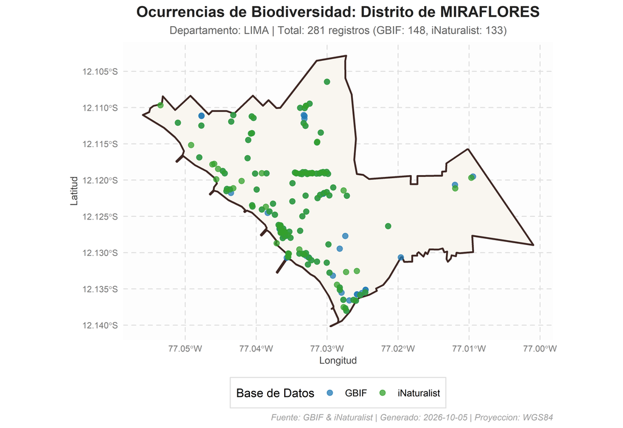

```r
# Visualizar diferenciando aportes de GBIF vs iNaturalist
mapa_fuente <- graficar_ocurrencias(
  resultado_lista = resultado,
  color_por = "source"
)

print(mapa_fuente)
```

### Comparación por Reino Biológico (`kingdom`)

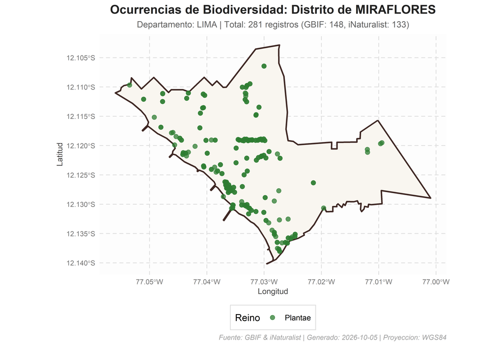

```r
# Visualizar distribución por reinos (Plantae, Animalia, Fungi, etc.)
mapa_reino <- graficar_ocurrencias(
  resultado_lista = resultado,
  color_por = "kingdom"
)

print(mapa_reino)
```

### Personalización con Capas de `ggplot2`

Dado que `graficar_ocurrencias()` retorna un objeto estándar de clase `ggplot`, puedes extenderlo y personalizarlo con cualquier tema, escala o etiqueta de `ggplot2`:

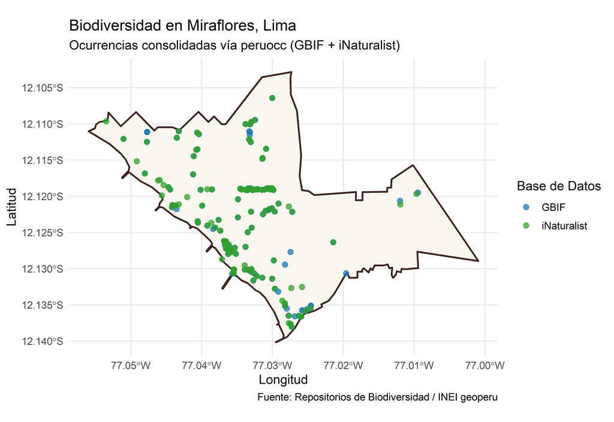

```r
library(ggplot2)

mapa_personalizado <- mapa_fuente +
  ggplot2::theme_minimal(base_size = 12) +
  ggplot2::labs(
    title = "Biodiversidad en Miraflores, Lima",
    subtitle = "Ocurrencias consolidadas vía peruocc (GBIF + iNaturalist)",
    caption = "Fuente: Repositorios de Biodiversidad / INEI geoperu"
  )

print(mapa_personalizado)
```

### Exportar el Mapa Directamente a Imagen

```r
# Genera y guarda automáticamente el mapa en results/ en formato PNG a 300 DPI
mapa_guardado <- graficar_ocurrencias(
  resultado_lista = resultado,
  color_por = "source",
  guardar_mapa = TRUE
)
```

## 5. Auditoría Científica: Estructura del Manifiesto JSON

El archivo `manifiesto_*.json` almacena metadatos críticos para publicaciones científicas y auditorías reproducibles:

```json
{
  "timestamp_utc": "2026-08-29T15:00:00Z",
  "paquetes": {
    "peruocc": "0.1.0",
    "sf": "1.0-19",
    "rgbif": "3.8.5",
    "rinat": "0.1.10"
  },
  "parametros": {
    "unidad": "Miraflores",
    "nivel": "distrito",
    "departamento": "Lima",
    "grupo": "flora",
    "limite_por_api": 150
  },
  "archivos_generados": [
    "ocurrencias_distrito_miraflores_flora.csv",
    "ocurrencias_distrito_miraflores_flora.geojson"
  ]
}
```

## 6. Integración con SIG y Flujos Espaciales

Las capas GeoJSON generadas pueden volver a cargarse en R para análisis espaciales posteriores (como modelos de distribución de especies o buffers):

```r
library(sf)

# Cargar la capa de ocurrencias exportada
capa_ocurrencias <- sf::st_read("peruocc-output/processed/ocurrencias_distrito_miraflores_flora.geojson")

# Inspección rápida
print(capa_ocurrencias)
```